# From pixels to patterns

## Packages and data

Graphical representation of estimates

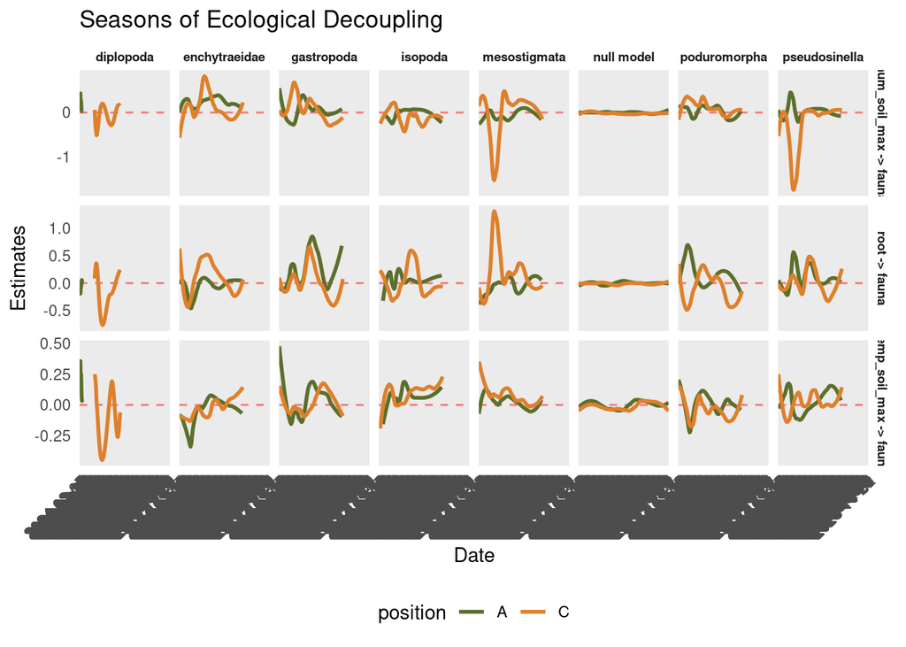

## Temporal stability of ecological “rules”

How consistently environmental factors drive soil fauna activity over time. By calculating the Coefficient of Variation (CV) for each SEM path, we distinguish between “steady” forcing (low CV), where the environment has a predictable impact, and “pulsed” or “unstable” forcing (high CV), where the relationship fluctuates. Comparing these across management positions allows us to test if human intensification destabilizes the ecosystem by replacing natural, steady rhythms with erratic, unpredictable biological responses.

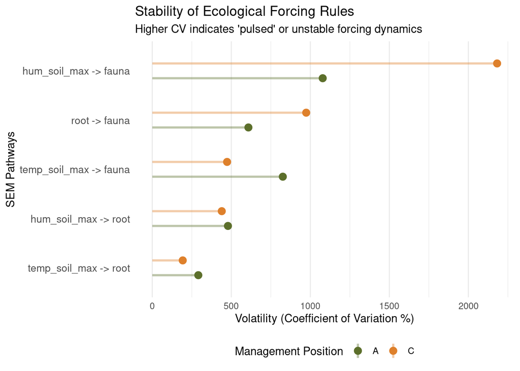

> **Pistes amélioration ou développement ?**

> générer CV selon plus de facteurs pour pouvoir faire tests de comparaison

> est-ce le CV est le meilleur indicateur de variation/stabilité temporelle ?

> ne sélectionner au préalable que les relations significatives ?

> décortiquer davantage les variations temporelles en identifiant les transitions abruptes ?

## Spatial Synchrony of Forcing

hen Temperature becomes a strong driver in the “Natural” zone, does it also become a strong driver in the “Anthropized” zone?

- High Correlation ($r \approx 1$): The management hasn’t changed the “timing” of the rule. The forcing remains governed by regional climate.
- Low/No Correlation ($r \approx 0$): Management has “decoupled” the site from the natural rhythm. The rules of the game in the anthropized zone are now independent of the natural ones.

```
# A tibble: 35 × 4
# Groups:   path_id [5]
   path_id               taxon         r_A_vs_C n_obs
   <chr>                 <chr>            <dbl> <int>
 1 hum_soil_max -> fauna enchytraeidae   0.129    376
 2 hum_soil_max -> fauna gastropoda      0.0191   379
 3 hum_soil_max -> fauna isopoda         0.0728   353
 4 hum_soil_max -> fauna mesostigmata    0.111    380
 5 hum_soil_max -> fauna null model      0.0142   607
 6 hum_soil_max -> fauna poduromorpha    0.0349   376
 7 hum_soil_max -> fauna pseudosinella   0.155    379
 8 hum_soil_max -> root  enchytraeidae   0.0510   376
 9 hum_soil_max -> root  gastropoda      0.0391   379
10 hum_soil_max -> root  isopoda         0.0368   353
11 hum_soil_max -> root  mesostigmata    0.0494   380
12 hum_soil_max -> root  null model     -0.0520   607
13 hum_soil_max -> root  poduromorpha    0.239    376
14 hum_soil_max -> root  pseudosinella   0.0482   379
15 root -> fauna         enchytraeidae   0.0964   376
# ℹ 20 more rows
```

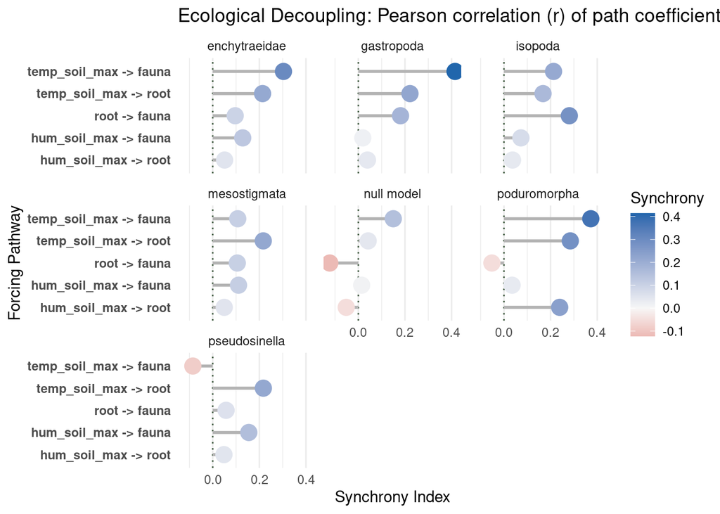

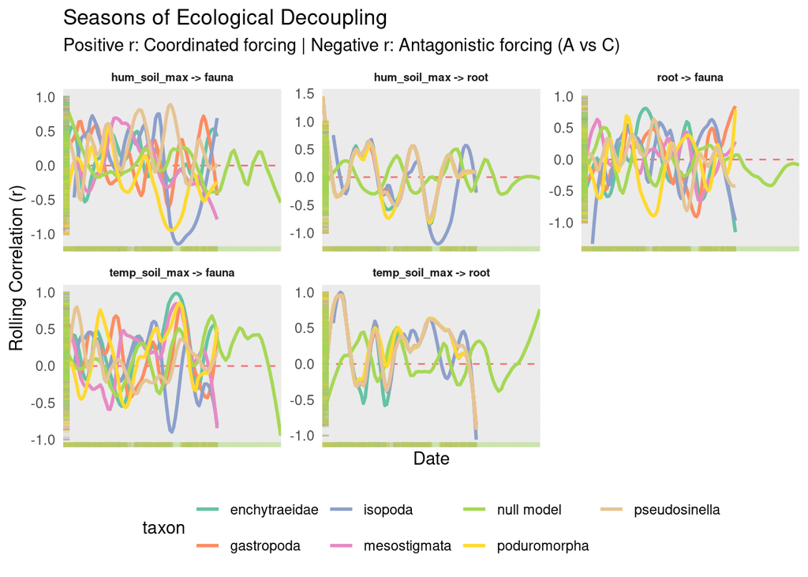